# Лекція 11. Побудова рекомендаційної системи з нуля

### Зміст

1. Що таке рекомендаційна система?
2. Навіщо потрібні рекомендаційні системи?
3. Як це працює?
4. Колаборативна фільтрація
5. Контентна фільтрація
6. Практичний приклад на основі набору даних MovieLens

# 1. Що таке рекомендаційна система?

- Один із напрямів застосування машинного навчання.
- Передбачає вподобання користувача щодо певного об’єкта.
- Спрямована на підвищення залученості користувачів.

# Приклади рекомендаційних систем

[figure not shown]

# Приклади рекомендаційних систем

[figure not shown]

# Приклади рекомендаційних систем

[figure not shown]

# 2. Навіщо потрібні рекомендаційні системи?

### До появи електронної комерції...

Товари продавалися виключно у традиційних фізичних магазинах

[figure not shown]

обмежений асортимент

масові товари

# Навіщо потрібні рекомендаційні системи?

### Електронна комерція...

Поява онлайн-ринку

[figure not shown]

необмежений асортимент

нішеві товари

# Навіщо потрібні рекомендаційні системи?

"Однак розвиток онлайн-торгівлі привів до усвідомлення того, що можливість динамічно перекатегоризовувати та переупорядковувати товари розкриває їхню справжню цінність." — Chris Anderson

[figure not shown]

# Навіщо потрібні рекомендаційні системи?

Експеримент із дегустаційним стендом (Iyengar and Lepper, 2000)

[figure not shown]

"30% споживачів в умовах обмеженого вибору згодом придбали банку джему; натомість в умовах широкого вибору це зробили лише 3% споживачів"

# 3. Як це працює

# Рекомендаційні системи = машинне навчання

[figure not shown]

# Рекомендаційні системи = машинне навчання

[figure not shown]

# Рекомендаційні системи = машинне навчання

[figure not shown]

# Рекомендаційні системи = машинне навчання

[figure not shown]

# 4. Колаборативна фільтрація

- Ґрунтується на припущенні, що подібні користувачі вподобують подібні об’єкти.
- "Користувачі, які придбали цей товар, також придбали..."
- "Оскільки ви переглянули фільм X..."

[figure not shown]

Матриця «користувач-об’єкт» («матриця корисності»)

# 5. Контентна фільтрація

- Формує рекомендації на основі ознак користувача та об’єкта.
- Дає змогу частково розв’язати проблему холодного старту для нових користувачів і нових об’єктів.
- Ознаки користувача: `age`, `gender`, `spoken language`.
- Ознаки об’єкта: `movie genre`, `year of release`, `cast`.

[figure not shown]

# 6. Практичний приклад

Побудувати рекомендаційну систему типу item-item на основі набору даних [MovieLens](https://movielens.org/).

# Крок 1. Імпорт залежностей

Подамо дані у вигляді **Pandas DataFrame**.

- Двовимірна структура даних.
- `columns` відповідають ознакам, `rows` відповідають об’єктам.
- Аналогічна до аркуша Excel або таблиці SQL.

```python
import numpy as np
import pandas as pd
import sklearn
import matplotlib.pyplot as plt
import seaborn as sns

import plotly.graph_objects as go
from plotly.subplots import make_subplots
from scipy.stats import gaussian_kde

%matplotlib inline
%config InlineBackend.figure_format = 'retina'
sns.set_style("whitegrid")
plt.rcParams['figure.dpi'] = 150
```

# Крок 2. Завантаження даних

- Завантажте набір даних MovieLens [тут](https://grouplens.org/datasets/movielens/).
- Він складається з двох файлів: – `ratings.csv` – `movies.csv`
- До цих файлів також можна звернутися безпосередньо за такими посиланнями: – https://s3-us-west-2.amazonaws.com/recommender-tutorial/ratings.csv – https://s3-us-west-2.amazonaws.com/recommender-tutorial/movies.csv

### Оцінки

DataFrame містить 4 стовпці:

- `userId`
- `movieId`
- `rating`
- `timestamp`

Ці дані потрібні для виконання колаборативної фільтрації.

```python
ratings = pd.read_csv("https://raw.githubusercontent.com/radiukpavlo/intelligent-data-analysis/refs/heads/main/01_lecture-notes/ida_lecture-11_recommendation/ratings.csv")

ratings.head()
```

|  | userId | movieId | rating | timestamp |
| --- | --- | --- | --- | --- |
| 0 | 1 | 1 | 4.0 | 964982703 |
| 1 | 1 | 3 | 4.0 | 964981247 |
| 2 | 1 | 6 | 4.0 | 964982224 |
| 3 | 1 | 47 | 5.0 | 964983815 |
| 4 | 1 | 50 | 5.0 | 964982931 |

### Фільми

DataFrame містить 3 стовпці:

- `movieId`;
- `title`;
- `genres`.

Ці дані потрібні для інтерпретації результатів рекомендаційної системи на основі колаборативної фільтрації.

```python
movies = pd.read_csv("https://raw.githubusercontent.com/radiukpavlo/intelligent-data-analysis/refs/heads/main/01_lecture-notes/ida_lecture-11_recommendation/movies.csv")

movies.head(3)
```

|  | movieId | title | genres |
| --- | --- | --- | --- |
| 0 | 1 | Toy Story (1995) | Adventure\|Animation\|Children\|Comedy\|Fantasy |
| 1 | 2 | Jumanji (1995) | Adventure\|Children\|Fantasy |
| 2 | 3 | Grumpier Old Men (1995) | Comedy\|Romance |

# Крок 3. Розвідувальний аналіз даних

`Ratings` містить оцінки, які користувачі виставили певним фільмам. Розглянемо, скільки оцінок, унікальних фільмів і унікальних користувачів містить наш набір даних.

```python
n_ratings = len(ratings)
n_movies = ratings['movieId'].nunique()
n_users = ratings['userId'].nunique()
```

```python
print(f"Number of ratings: {n_ratings}")
print(f"Number of unique movieId's: {n_movies}")
print(f"Number of unique users: {n_users}")
print(f"Average number of ratings per user: {round(n_ratings/n_users, 2)}")
print(f"Average number of ratings per movie: {round(n_ratings/n_movies, 2)}")
```

```
Number of ratings: 100836
Number of unique movieId's: 9724
Number of unique users: 610
Average number of ratings per user: 165.3
Average number of ratings per movie: 10.37
```

Скільки оцінок поставив кожен користувач? Скористаймося функціями pandas `groupby()` і `count()`, щоб:

1. згрупувати дані за `userId`;
2. підрахувати кількість оцінок для кожного `userId`.

```python
user_freq = ratings[['userId', 'movieId']].groupby('userId').count().reset_index()
user_freq.columns = ['userId', 'n_ratings']
user_freq.head()
```

|  | userId | n_ratings |
| --- | --- | --- |
| 0 | 1 | 232 |
| 1 | 2 | 29 |
| 2 | 3 | 39 |
| 3 | 4 | 216 |
| 4 | 5 | 44 |

```python
mean_n_ratings = user_freq['n_ratings'].mean()
print(f"Mean number of ratings for a given user: {mean_n_ratings:.2f}.")
```

```
Mean number of ratings for a given user: 165.30.
```

Візуалізуймо розподіл оцінок фільмів у цьому наборі даних, а також розподіл частоти оцінювання користувачами. Для цього можна використати пакет Python [seaborn](https://seaborn.pydata.org/).

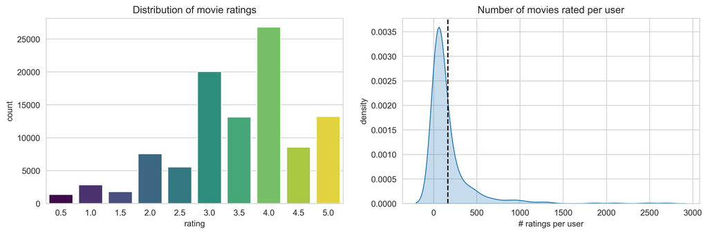

```python
plt.figure(figsize=(14,4))
plt.subplot(1,2,1) # PLOT 1
ax = sns.countplot(x="rating", data=ratings, palette="viridis", hue="rating", legend=False)
ax.set(title="Distribution of movie ratings")
plt.subplot(1,2,2) # PLOT 2
ax = sns.kdeplot(user_freq['n_ratings'], fill=True, legend=False)
ax.set(title="Number of movies rated per user", xlabel="# ratings per user", ylabel="density")
plt.axvline(user_freq['n_ratings'].mean(), color="k", linestyle="--")
plt.show()
```

### Які фільми мають найвищі та найнижчі середні оцінки?

Щоб визначити «найкращі» та «найгірші» фільми, потрібно обчислити середню оцінку для кожного фільму в нашому наборі даних. Це можна зробити, згрупувавши дані за `movieId` та обчисливши середнє значення стовпця `rating`.

```python
mean_rating = ratings.groupby('movieId')[['rating']].mean()
mean_rating.head()
```

| movieId | rating |
| --- | --- |
| 1 | 3.920930 |
| 2 | 3.431818 |
| 3 | 3.259615 |
| 4 | 2.357143 |
| 5 | 3.071429 |

### Які фільми мають найвищі та найнижчі середні оцінки?

```python
lowest_rated = mean_rating['rating'].idxmin()
movies.loc[movies['movieId'] == lowest_rated]
```

|  | movieId | title | genres |
| --- | --- | --- | --- |
| 2689 | 3604 | Gypsy (1962) | Musical |

```python
highest_rated = mean_rating['rating'].idxmax()
movies.loc[movies['movieId'] == highest_rated]
```

|  | movieId | title | genres |
| --- | --- | --- | --- |
| 48 | 53 | Lamerica (1994) | Adventure\|Drama |

[figure not shown]

### Фільм Lamerica має найвищий рейтинг?!

Імовірно, цей фільм справді якісний, однак його навряд чи можна вважати широко відомим. Розгляньмо глибше, хто саме оцінив цей фільм.

```python
ratings.loc[ratings['movieId']==highest_rated]
```

|  | userId | movieId | rating | timestamp |
| --- | --- | --- | --- | --- |
| 13368 | 85 | 53 | 5.0 | 889468268 |
| 96115 | 603 | 53 | 5.0 | 963180003 |

Хоча Lamerica має найвищу середню оцінку, він отримав лише 2 оцінки. Це не є надійним показником популярності фільму. Якість оцінювання фільму визначається не лише середнім балом, а й кількістю отриманих оцінок.

# Байєсівське середнє

- Зважене середнє, яке враховує кількість наявних оцінок.
- Доцільне, коли доступно небагато даних.
- Широко використовується у спортивній статистиці (наприклад, для batting average).
- Обчислюється за такою формулою:

$$r_{i} = \frac{C \times m + \Sigma{\text{ratings}}}{C+N}, $$

де:

- $C$ – наш рівень довіри (середня кількість оцінок для заданого фільму);
- $m$ – апріорна оцінка (глобальна середня оцінка);
- $N$ – загальна кількість оцінок для фільму $i$.

Спочатку потрібно отримати `count` і `mean` для кожного фільму в нашому наборі даних. Це можна зробити за допомогою розширеного `groupby`, який одночасно застосовує `mean` і `count` через метод `agg`.

```python
movie_stats = ratings.groupby('movieId')[['rating']].agg(['count', 'mean'])
movie_stats.columns = movie_stats.columns.droplevel()
movie_stats.head()
```

| movieId | count | mean |
| --- | --- | --- |
| 1 | 215 | 3.920930 |
| 2 | 110 | 3.431818 |
| 3 | 52 | 3.259615 |
| 4 | 7 | 2.357143 |
| 5 | 49 | 3.071429 |

Обчислимо байєсівське середнє. Спочатку запишемо функцію, яка обчислює байєсівське середнє для заданого фільму.

```python
C = movie_stats['count'].mean()
m = movie_stats['mean'].mean()

def bayesian_avg(ratings_i):
    bayesian_avg = (C*m+ratings_i.sum())/(C+ratings_i.count())
    return bayesian_avg
```

Можемо застосувати `bayesian_avg` до всього набору даних з оцінками за допомогою методу `agg`.

```python
bayesian_avg_ratings = ratings.groupby('movieId')['rating'].agg(bayesian_avg).reset_index()
bayesian_avg_ratings.columns = ['movieId', 'bayesian_avg']
bayesian_avg_ratings.head()
```

|  | movieId | bayesian_avg |
| --- | --- | --- |
| 0 | 1 | 3.890632 |
| 1 | 2 | 3.417227 |
| 2 | 3 | 3.260086 |
| 3 | 4 | 2.897612 |
| 4 | 5 | 3.104793 |

Які фільми мають найвище байєсівське середнє значення оцінки?

```python
movie_stats = movie_stats.merge(bayesian_avg_ratings, on='movieId')
movie_stats = movie_stats.merge(movies[['movieId', 'title']])
movie_stats.sort_values('bayesian_avg', ascending=False).head()
```

|  | movieId | count | mean | bayesian_avg | title |
| --- | --- | --- | --- | --- | --- |
| 277 | 318 | 317 | 4.429022 | 4.392070 | Shawshank Redemption, The (1994) |
| 659 | 858 | 192 | 4.289062 | 4.236457 | Godfather, The (1972) |
| 2224 | 2959 | 218 | 4.272936 | 4.227052 | Fight Club (1999) |
| 224 | 260 | 251 | 4.231076 | 4.192646 | Star Wars: Episode IV - A New Hope (1977) |
| 46 | 50 | 204 | 4.237745 | 4.190567 | Usual Suspects, The (1995) |

Використання байєсівського середнього показує, що Lamerica більше не є фільмом із найвищою оцінкою.

Які фільми мають найнижче байєсівське середнє значення оцінки?

```python
movie_stats.sort_values('bayesian_avg', ascending=True).head()
```

|  | movieId | count | mean | bayesian_avg | title |
| --- | --- | --- | --- | --- | --- |
| 1172 | 1556 | 19 | 1.605263 | 2.190377 | Speed 2: Cruise Control (1997) |
| 2679 | 3593 | 19 | 1.657895 | 2.224426 | Battlefield Earth (2000) |
| 1372 | 1882 | 33 | 1.954545 | 2.267268 | Godzilla (1998) |
| 1144 | 1499 | 27 | 1.925926 | 2.296800 | Anaconda (1997) |
| 1988 | 2643 | 16 | 1.687500 | 2.306841 | Superman IV: The Quest for Peace (1987) |

# Крок 4. Перетворення даних

- Потрібно перетворити дані на матрицю «користувач-об’єкт» для колаборативної фільтрації.
- [scipy.sparse_matrix](https://docs.scipy.org/doc/scipy/reference/sparse.html): стовпці відповідають фільмам, а рядки – користувачам.
- Кожна комірка містить оцінку, яку користувач поставив фільму.
- Порожня комірка = оцінка відсутня.

[figure not shown]

```python
from scipy.sparse import csr_matrix

def create_X(df):
    """
    Generates a sparse matrix from the ratings dataframe.

    Args:
        df: ratings dataframe

    Returns:
        X: sparse matrix
        user_mapper: dict that maps user id's to user indices
        user_inv_mapper: dict that maps user indices to user id's
        movie_mapper: dict that maps movie id's to movie indices
        movie_inv_mapper: dict that maps movie indices to movie id's
    """
    N = df['userId'].nunique()
    M = df['movieId'].nunique()

    user_mapper = dict(zip(np.unique(df["userId"]), list(range(N))))
    movie_mapper = dict(zip(np.unique(df["movieId"]), list(range(M))))
    user_inv_mapper = dict(zip(list(range(N)), np.unique(df["userId"])))
    movie_inv_mapper = dict(zip(list(range(M)), np.unique(df["movieId"])))

    user_index = [user_mapper[i] for i in df['userId']]
    movie_index = [movie_mapper[i] for i in df['movieId']]

    X = csr_matrix((df["rating"], (movie_index, user_index)), shape=(M, N))

    return X, user_mapper, movie_mapper, user_inv_mapper, movie_inv_mapper
```

```python
X, user_mapper, movie_mapper, user_inv_mapper, movie_inv_mapper =create_X(ratings)
```

### Обчислення розрідженості матриці

Розгляньмо, наскільки розрідженою є наша матриця $X$. Щільність матриці $d$ можна обчислити за такою формулою:

$$ d=\frac{\text{num non-zero elements}}{\text{total elements}}. $$

```python
density = X.count_nonzero()/(X.shape[0]*X.shape[1])

print(f"Matrix density: {round(density*100,2)}%")
```

```
Matrix density: 1.7%
```

Наша матриця є досить розрідженою. Однак це типовий випадок для матриць типу «користувач-об’єкт». Загальне практичне правило полягає в тому, що щільність матриці не повинна бути нижчою за 0.5%, якщо очікується отримання прийнятних результатів.

### Як зберегти розріджену матрицю

Щоб зберегти розріджену матрицю для подальшого аналізу, можна використати [метод](https://docs.scipy.org/doc/scipy/reference/generated/scipy.sparse.save_npz.html) `save_npz` для розріджених матриць із scipy.

```python
from scipy.sparse import save_npz, load_npz

save_npz('user_item_matrix.npz', X)
```

Її можна знову завантажити за допомогою `load_npz`.

```python
X = load_npz('user_item_matrix.npz')
X
```

```
<Compressed Sparse Row sparse matrix of dtype 'float64'
	with 100836 stored elements and shape (9724, 610)>
```

# Крок 5. Пошук подібних фільмів за допомогою k-Nearest Neighbours

k-Nearest Neighbours (kNN) – це алгоритм класифікації, який передбачає мітку заданого зразка на основі голосування більшості поміж його найближчих $k$ сусідів.

[figure not shown]

Відстань між двома зразками можна вимірювати за допомогою `cosine similarity`, `Euclidean distance`, `Manhattan distance` тощо.

### Cosine Similarity та Euclidean Distance

- **Cosine Similarity**: вимірює подібність двох точок за їхньою орієнтацією (тобто за косинусом кута між $A$ та $B$):
  - чим ближче значення cosine similarity до 1, тим подібнішими є об’єкти:

$$ \text{similairity}=\frac{A \cdot B}{\mid{A}\mid\mid{B}\mid}. $$

- **Euclidean Distance**: вимірює відстань між двома об’єктами у $n$-вимірному просторі (тобто довжину прямої між $A$ та $B$):
  - на відміну від cosine similarity, Euclidean distance враховує масштаб:

$$ d(p,q) = \sqrt{(p_1-q_1)^2 + (p_2-q_2)^2 + ... + (p_n-q_n)^2}. $$

### Cosine Similarity та Euclidean Distance

[figure not shown]

- Пари A-B і D-E мають однакову cosine similarity.
- Для A-B Euclidean distance менша, ніж для D-E.

Створимо функцію, яка знаходить $k$ подібних фільмів для заданого фільму.

```python
from sklearn.neighbors import NearestNeighbors

def find_similar_movies(movie_id, X, k, metric='cosine', show_distance=False):
    """
    Finds k-nearest neighbours for a given movie id.

    Args:
        movie_id: id of the movie of interest
        X: user-item utility matrix
        k: number of similar movies to retrieve
        metric: distance metric for kNN calculations

    Returns:
        list of k similar movie ID's
    """
    neighbour_ids = []

    movie_ind = movie_mapper[movie_id]
    movie_vec = X[movie_ind]
    k+=1
    kNN = NearestNeighbors(n_neighbors=k, algorithm="brute", metric=metric)
    kNN.fit(X)
    if isinstance(movie_vec, (np.ndarray)):
        movie_vec = movie_vec.reshape(1,-1)
    neighbour = kNN.kneighbors(movie_vec, return_distance=show_distance)
    for i in range(0,k):
        n = neighbour.item(i)
        neighbour_ids.append(movie_inv_mapper[n])
    neighbour_ids.pop(0)
    return neighbour_ids
```

Перевіримо роботу нашої функції, передавши `movieId`. Створимо словник, який відображає `movieId` на назву фільму, щоб результати було легше інтерпретувати.

У цьому випадку `movie_id = 1` відповідає Toy Story. Встановимо `k = 10` і використаємо метрику за замовчуванням – `cosine similarity`. Це означає, що ми шукаємо 10 фільмів, найбільш подібних до Toy Story.

```python
movie_titles = dict(zip(movies['movieId'], movies['title']))

movie_id = 1

similar_ids = find_similar_movies(movie_id, X, k=10)
movie_title = movie_titles[movie_id]

print(f"Because you watched {movie_title}...")
for i in similar_ids:
    print(movie_titles[i])
```

```
Because you watched Toy Story (1995)...
Toy Story 2 (1999)
Jurassic Park (1993)
Independence Day (a.k.a. ID4) (1996)
Star Wars: Episode IV - A New Hope (1977)
Forrest Gump (1994)
Lion King, The (1994)
Star Wars: Episode VI - Return of the Jedi (1983)
Mission: Impossible (1996)
Groundhog Day (1993)
Back to the Future (1985)
```

Повторімо цей процес, але тепер використаємо Euclidean distance.

```python
movie_titles = dict(zip(movies['movieId'], movies['title']))

movie_id = 1
similar_ids = find_similar_movies(movie_id, X, k=10, metric="euclidean")

movie_title = movie_titles[movie_id]
print(f"Because you watched {movie_title}...")
for i in similar_ids:
    print(movie_titles[i])
```

```
Because you watched Toy Story (1995)...
Toy Story 2 (1999)
Mission: Impossible (1996)
Independence Day (a.k.a. ID4) (1996)
Bug's Life, A (1998)
Nutty Professor, The (1996)
Willy Wonka & the Chocolate Factory (1971)
Babe (1995)
Groundhog Day (1993)
Mask, The (1994)
Honey, I Shrunk the Kids (1989)
```

# Зменшення розмірності за допомогою факторизації матриць

### (Поглиблений матеріал)

### Факторизація матриць

- Метод лінійної алгебри, який допомагає виявляти латентні ознаки між користувачами та фільмами.
- Латентні (приховані) ознаки забезпечують компактніше подання смаків користувачів і характеристик об’єктів.
- Може підвищити якість рекомендацій, коли матриця $X$ є дуже розрідженою.
- Розкладає матрицю «користувач-об’єкт» на дві «факторні матриці»: – матрицю користувацьких факторів `(n_users, k)`; – матрицю факторів об’єктів `(k, n_items)`.

[figure not shown]

### Сингулярний розклад матриці

- Singular Value Decomposition (SVD) – це один із різновидів факторизації матриць, який використовують для зменшення обсягу даних і приглушення шуму
- [scikit-learn](https://scikit-learn.org/stable/modules/generated/sklearn.decomposition.TruncatedSVD.html) містить клас `TruncatedSVD`, який можна використати для зменшення розмірності нашої матриці з `(n_users, n_movies)` до `(n_users, n_components)`, де `n_components` означає кількість латентних ознак.

```python
from sklearn.decomposition import TruncatedSVD

svd = TruncatedSVD(n_components=25, n_iter=10)
Z = svd.fit_transform(X.T)
print(f"The shape of our compressed Z matrix is: {Z.shape}.")
```

```
The shape of our compressed Z matrix is: (610, 25).
```

Застосуємо нашу функцію `find_similar_movies` до нової матриці `Z`.

```python
movie_id = 1
similar_movies = find_similar_movies(movie_id, X=Z.T, metric='cosine', k=10)
movie_title = movie_titles[movie_id]

print(f"Because you watched {movie_title}:")
for i in similar_movies:
    print(movie_titles[i])
```

```
Because you watched Toy Story (1995):
Casino (1995)
Cutthroat Island (1995)
Waiting to Exhale (1995)
Sense and Sensibility (1995)
Heat (1995)
Leaving Las Vegas (1995)
Sudden Death (1995)
Money Train (1995)
Ace Ventura: When Nature Calls (1995)
GoldenEye (1995)
```

### Рекомендаційна система Top N

- Факторизація матриць дає змогу передбачати відсутні оцінки у вихідній матриці $X$.
- Відновлюємо матрицю, обчислюючи внутрішній добуток матриці користувацьких факторів і матриці факторів фільмів.

```python
new_X = svd.inverse_transform(Z).T

print(f"Dimensions of original user-item matrix: {X.shape}, {type(X)}")
print(f"Dimensions of SVD-reconstructed X matrix: {new_X.shape}, {type(new_X)}")
```

```
Dimensions of original user-item matrix: (9724, 610), <class 'scipy.sparse._csr.csr_matrix'>
Dimensions of SVD-reconstructed X matrix: (9724, 610), <class 'numpy.ndarray'>
```

Спробуймо згенерувати рекомендації Top N для користувача з нашого набору даних. Розглянемо `userId` 5. Які фільми цей користувач оцінив найвище?

```python
userId = 5
user_preferences = ratings[(ratings['userId']==userId)&(ratings['rating']>=4)]
user_preferences = user_preferences.merge(movies[['movieId', 'title']])
user_preferences.sort_values('rating', ascending=False).head(5)
```

|  | userId | movieId | rating | timestamp | title |
| --- | --- | --- | --- | --- | --- |
| 5 | 5 | 58 | 5.0 | 847435238 | Postman, The (Postino, Il) (1994) |
| 20 | 5 | 594 | 5.0 | 847435238 | Snow White and the Seven Dwarfs (1937) |
| 19 | 5 | 590 | 5.0 | 847434747 | Dances with Wolves (1990) |
| 21 | 5 | 595 | 5.0 | 847434832 | Beauty and the Beast (1991) |
| 11 | 5 | 296 | 5.0 | 847434748 | Pulp Fiction (1994) |

Тепер передбачимо, які фільми також можуть сподобатися користувачу `userId` 5 на основі його попередніх оцінок. Для цього потрібно виконати такі дії:

Можемо скористатися `np.argsort()`, щоб отримати верхні $N$ індексів для `userId=5`.

```python
top_N = 10

movie_titles = dict(zip(movies['movieId'], movies['title']))

top_N_indices = new_X[user_mapper[userId]].argsort()[-top_N:][::-1]

print(f"Top {top_N} Recommendations for UserId {userId}:")
for i in top_N_indices:
    movie_id = movie_inv_mapper[i]
    print(movie_titles[movie_id])
```

```
Top 10 Recommendations for UserId 5:
Puppet Masters, The (1994)
Heat (1995)
Beautiful Girls (1996)
Chasers (1994)
Timecop (1994)
Little Women (1994)
Birdcage, The (1996)
Twelve Monkeys (a.k.a. 12 Monkeys) (1995)
Bullets Over Broadway (1994)
Sliver (1993)
```